# Seal AA3 : étude de la précision

Engels Guyliann

2018-02-15

Abstract

Suite à une réunion d’équipe du lundi 11 février 2018, des expériences portant sur la précision du seal AA3 sont menée.

# 1 Les ions nitrites

Les ions nitrites ont été dosés le 2019-02-14 et les données sont dans le fichier 190214B-orga

|  | Méthode | Unité | Base | Gain | Lamp |
| --- | --- | --- | --- | --- | --- |
| channel_1 | Ptot | µmol/L | -5550 | 161 | 253 |
| channel_2 | Ntot | µmol/L | -6945 | 15 | 300 |
| channel_3 | NO2 | µmol/L | -7692 | 7 | 289 |

Après nettoyage des données, nous obtenons le graphique suivants montrant les concentrations obtenues au cours du temps.

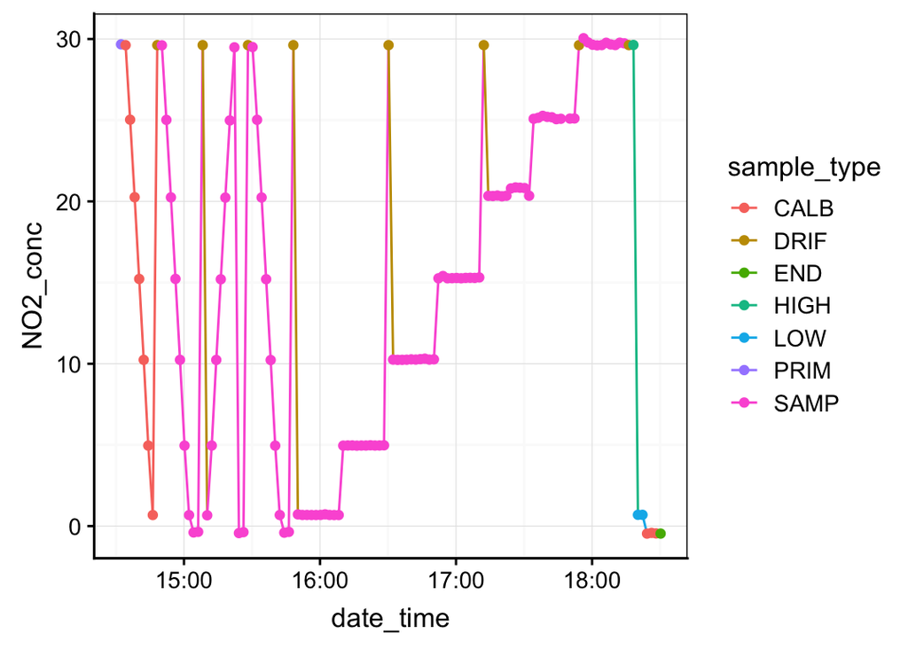

| Echantillons | Moyenne | Ecart-type | Coefficient de variation | n |
| --- | --- | --- | --- | --- |
| cal1 | 0.6861538 | 0.0161805 | 0.0235814 | 13 |
| cal5 | 4.9615385 | 0.0069356 | 0.0013979 | 13 |
| cal10 | 10.2542308 | 0.0225985 | 0.0022038 | 13 |
| cal15 | 15.2717692 | 0.0510949 | 0.0033457 | 13 |
| cal20 | 20.4650769 | 0.2557588 | 0.0124973 | 13 |
| cal25 | 25.1043333 | 0.0825627 | 0.0032888 | 12 |
| cal30 | 29.6817692 | 0.1446018 | 0.0048717 | 13 |
| mesoA | -0.4106667 | 0.0197569 | -0.0481092 | 3 |
| mesoB | -0.3620000 | 0.0096437 | -0.0266399 | 3 |

# 2 Phosphore totale

Le phosphore organique et inorganique dissous ont été dosés le 2019-02-13 et les données sont dans le fichier 190213AR6-orga.

|  | Méthode | Unité | Base | Gain | Lamp |
| --- | --- | --- | --- | --- | --- |
| channel_1 | Ptot | µmol/L | -5550 | 161 | 253 |
| channel_2 | Ntot | µmol/L | -6945 | 15 | 300 |
| channel_3 | NO2 | µmol/L | -7692 | 7 | 289 |

Après avoir nettoyé le fichier suite à un problème lié à la courbe de calibration (en rouge les points employés et en bleu la droite de calibration recalculée).

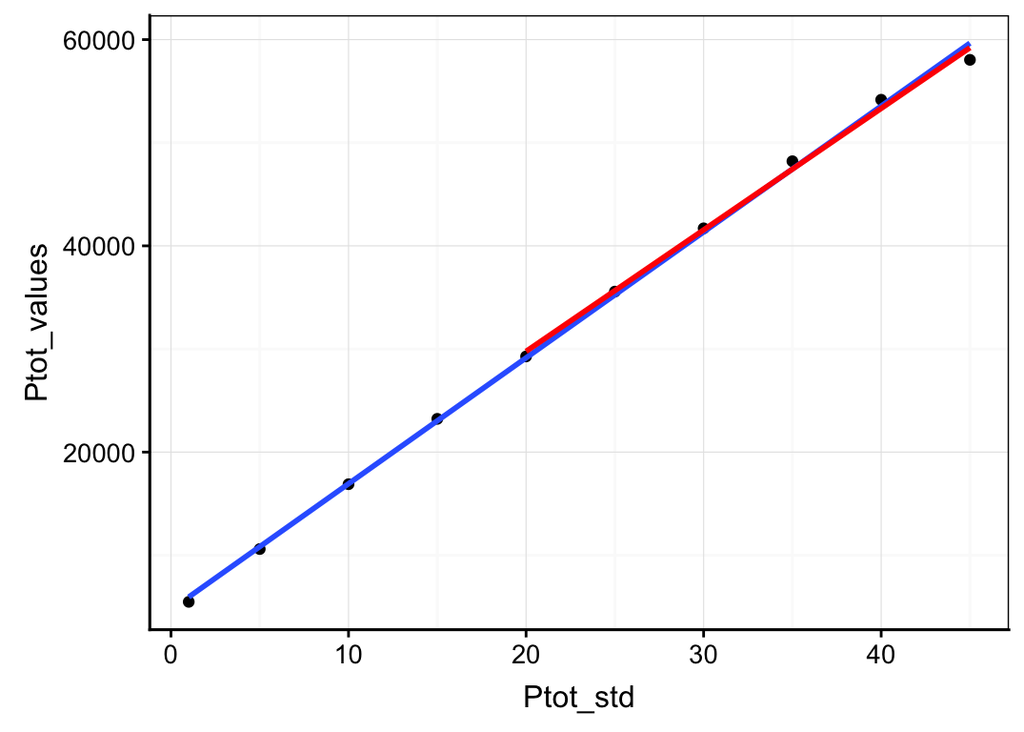

nous obtenons le graphique suivant

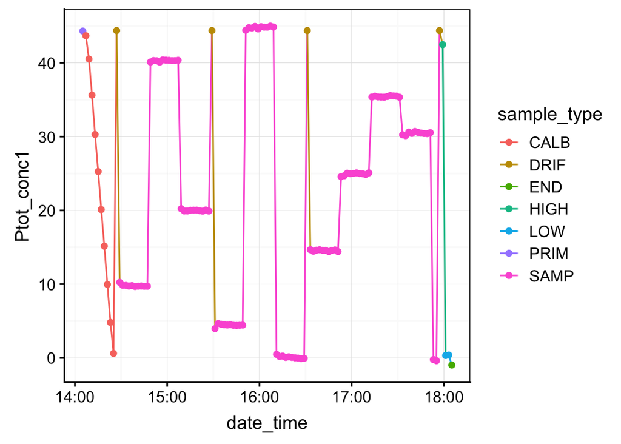

| Echantillons | Moyenne | Ecart-type | Coefficient de variation | n |
| --- | --- | --- | --- | --- |
| cal1 | 0.1091815 | 0.1748062 | 1.6010615 | 10 |
| cal5 | 4.4412150 | 0.1815139 | 0.0408703 | 10 |
| cal10 | 9.8098499 | 0.1604979 | 0.0163609 | 10 |
| cal15 | 14.5606527 | 0.0947280 | 0.0065058 | 10 |
| cal20 | 19.9964611 | 0.0955168 | 0.0047767 | 10 |
| cal25 | 24.9272397 | 0.1703142 | 0.0068325 | 10 |
| cal30 | 30.4508651 | 0.1695504 | 0.0055680 | 10 |
| cal35 | 35.4221935 | 0.0811989 | 0.0022923 | 10 |
| cal40 | 40.2787535 | 0.1026173 | 0.0025477 | 10 |
| cal45 | 44.7785569 | 0.1676945 | 0.0037450 | 10 |
| mesoA | -0.2166918 | NA | NA | 1 |
| mesoB | -0.3756144 | NA | NA | 1 |

Avec un changement de lentille (5 fois plus sensible) du colorimètre, nous pouvons espérer doser avec moins de 5 % d’erreur des concentrations de l’ordre de 1 µmol/L (malgré le recalcule de la droite de calibration).

# 3 Azote totale

L’azote organique et inorganique dissous ont été dosés en même temps que le phosphore totale.

Après avoir nettoyé le fichier suite à un problème lié à la courbe de calibration (voir Analyse du phosphore totale).

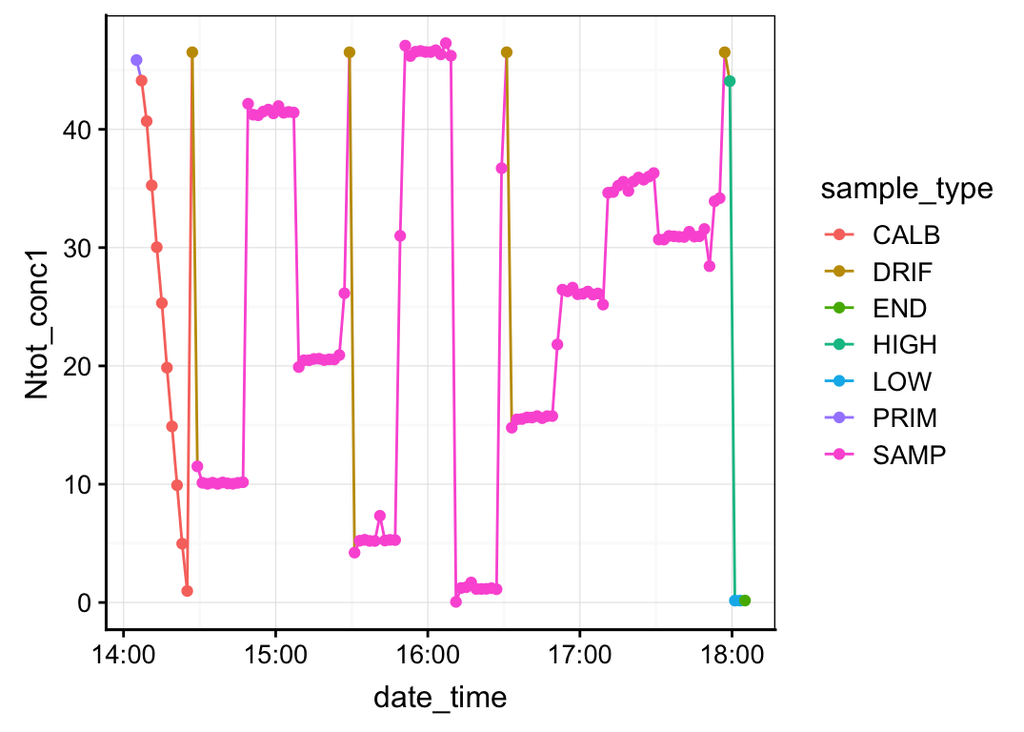

Malgré le recalcule de concentrations avec la nouvelle droite de calibration de nombreux points sont suspects.

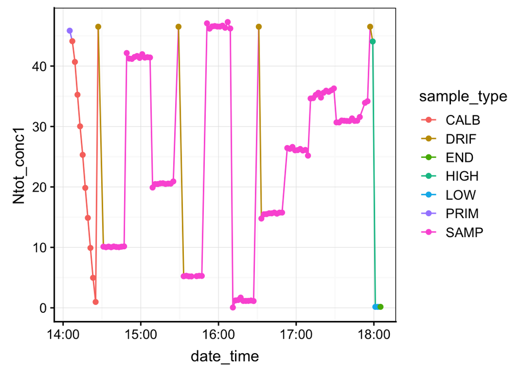

| Echantillons | Moyenne | Ecart-type | Coefficient de variation | n |
| --- | --- | --- | --- | --- |
| cal1 | 4.673897 | 11.2639780 | 2.4099754 | 10 |
| cal5 | 7.928393 | 8.1413858 | 1.0268646 | 10 |
| cal10 | 10.233876 | 0.4495191 | 0.0439246 | 10 |
| cal15 | 16.170543 | 2.0025632 | 0.1238402 | 10 |
| cal20 | 21.070266 | 1.7981122 | 0.0853388 | 10 |
| cal25 | 26.978576 | 2.7180459 | 0.1007483 | 10 |
| cal30 | 30.767824 | 0.8585849 | 0.0279053 | 10 |
| cal35 | 35.052643 | 1.6178171 | 0.0461539 | 10 |
| cal40 | 41.536318 | 0.3130015 | 0.0075356 | 10 |
| cal45 | 46.605018 | 0.3488425 | 0.0074851 | 10 |
| mesoA | 33.920431 | NA | NA | 1 |
| mesoB | 34.180741 | NA | NA | 1 |

Malgré le nettoyage des données, les coefficients de variation restent très élevé.

# 4 Phosphate

|  | Méthode | Unité | Base | Gain | Lamp |
| --- | --- | --- | --- | --- | --- |
| channel_1 | PO4 | µmol/L | -5645 | 47 | 257 |
| channel_2 | NOx | µmol/L | -6966 | 15 | 300 |
| channel_3 | NH4 | µmol/L | -8144 | 61 | 292 |

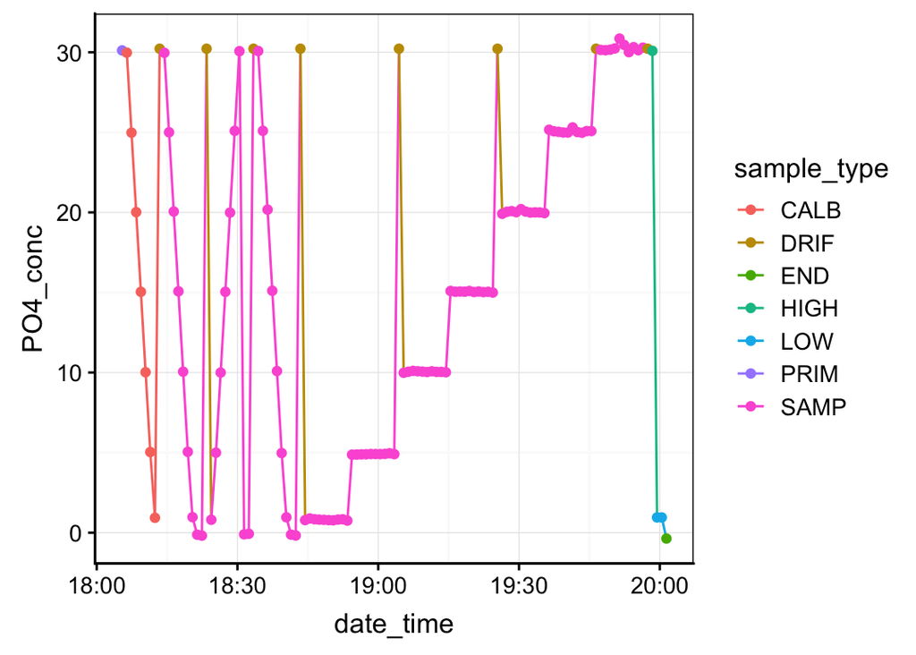

| Echantillons | Moyenne | Ecart-type | Coefficient de variation | n |
| --- | --- | --- | --- | --- |
| cal1 | 0.8340769 | 0.0674357 | 0.0808507 | 13 |
| cal5 | 4.9289231 | 0.0512371 | 0.0103952 | 13 |
| cal10 | 10.0491538 | 0.0353785 | 0.0035205 | 13 |
| cal15 | 15.0544615 | 0.0310339 | 0.0020614 | 13 |
| cal20 | 20.0354615 | 0.0807286 | 0.0040293 | 13 |
| cal25 | 25.0676154 | 0.0894684 | 0.0035691 | 13 |
| cal30 | 30.2176154 | 0.2330975 | 0.0077140 | 13 |

Avec un changement de lentille (5 fois plus sensible) du colorimètre, nous pouvons espérer doser avec 8 % d’erreur des concentrations de l’ordre de 0.2 µmol/L.

# 5 NOx

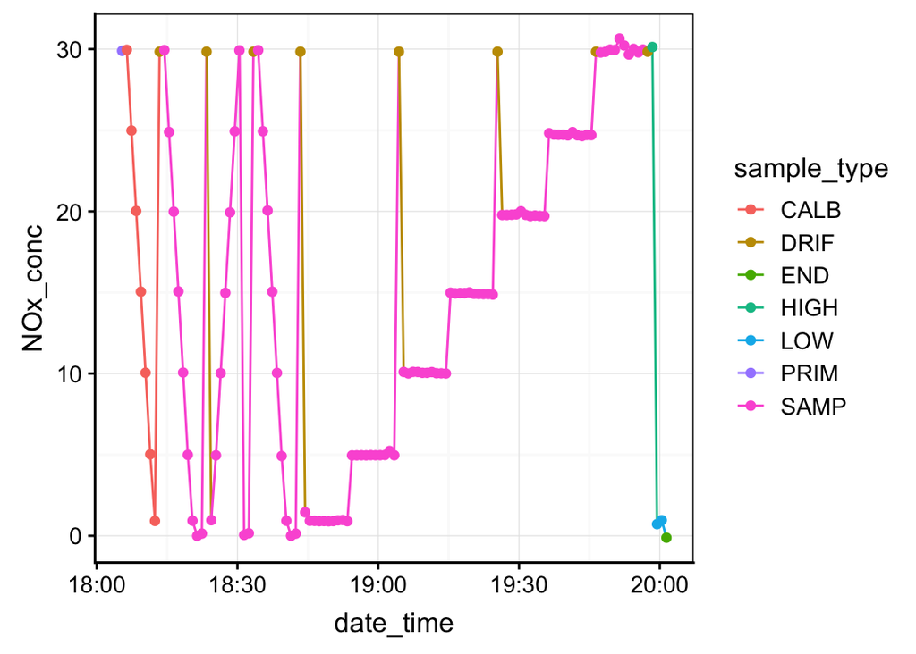

En retirant le premier point des dosages à 1µmol/L on obtient le tableau suivant :

| Echantillons | Moyenne | Ecart-type | Coefficient de variation | n |
| --- | --- | --- | --- | --- |
| cal1 | 0.923750 | 0.0259199 | 0.0280594 | 12 |
| cal5 | 4.983769 | 0.0758674 | 0.0152229 | 13 |
| cal10 | 10.050308 | 0.0376107 | 0.0037422 | 13 |
| cal15 | 14.955615 | 0.0585912 | 0.0039177 | 13 |
| cal20 | 19.829154 | 0.1196967 | 0.0060364 | 13 |
| cal25 | 24.773615 | 0.1043069 | 0.0042104 | 13 |
| cal30 | 29.976769 | 0.2426376 | 0.0080942 | 13 |

# 6 NH4

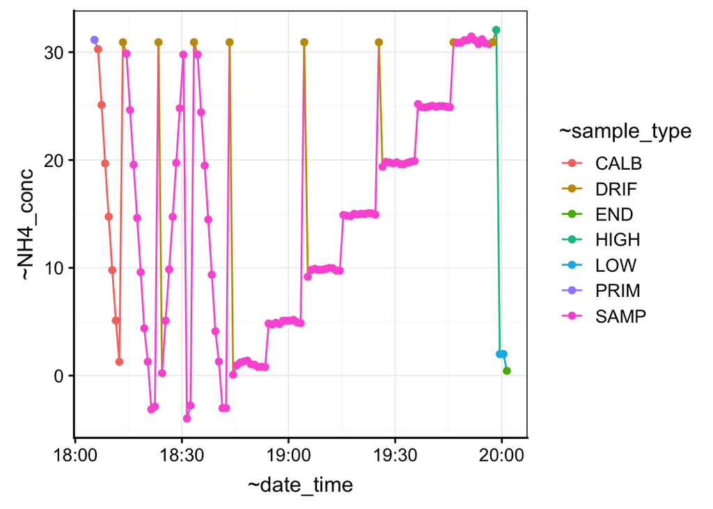

| Echantillons | Moyenne | Ecart-type | Coefficient de variation | n |
| --- | --- | --- | --- | --- |
| cal1 | 0.946000 | 0.4066598 | 0.4298729 | 13 |
| cal5 | 4.856231 | 0.3061337 | 0.0630394 | 13 |
| cal10 | 9.742846 | 0.2373229 | 0.0243587 | 13 |
| cal15 | 14.873000 | 0.1758574 | 0.0118239 | 13 |
| cal20 | 19.685769 | 0.1514057 | 0.0076911 | 13 |
| cal25 | 24.890692 | 0.1885243 | 0.0075741 | 13 |
| cal30 | 30.730846 | 0.5626122 | 0.0183077 | 13 |

Avec un changement de lentille (5 fois plus sensible) du colorimètre, nous pouvons espérer doser avec 6 % d’erreur des concentrations de l’ordre de 1 µmol/L.